# Real-data disturbance–response III — central tendency, variance & peak synchrony

The peak/moments approach on real MacroSheds precip→discharge — how the simplest synchrony method holds up off the idealised bench (cf. analysis I)

nic (nic@cascadeclimate.org)

2026-07-18

Unlike the synthetic driver, **daily precip is episodic, not a clean sine** and discharge carries snowmelt/storage lag and long-term trend — so read this as a stress-test of the peak/moments lens, not a search for a known answer. Where it strains (peaks fraying on storm-spiky series, an unstable period), that *is* the finding, and analysis IV takes the same sites into the wavelet view for contrast.

*Error-bar caveat (as in analysis I): the peak-metric SEs are block/sample SEs over the ~decades of annual cycles in each window — coarser than they look on autocorrelated series; read as relative guides.*

## Helpers

```r
# centered moving average (window w); NA at the ±(w-1)/2 ends — used for peak-finding only.
smooth_ma <- function(x, w = 61) as.numeric(stats::filter(x, rep(1 / w, w)))

# local maxima of a smoothed copy, thinned greedily by height to a minimum separation `gap`.
# Two noise defences: keep only candidates above the window mean, then greedy gap≈0.6P ⇒ ≤1
# peak/season. Real daily series are storm-spiky, so we smooth harder than analysis I (w≈2 months)
# to recover the seasonal peak rather than individual storms.
find_peaks <- function(x, w = 61, gap = round(0.6 * P)) {
  s <- smooth_ma(x, w); n <- length(s)
  interior <- s[2:(n - 1)] > s[1:(n - 2)] & s[2:(n - 1)] >= s[3:n]
  cand <- which(c(FALSE, interior, FALSE))            # NA comparisons drop out of which()
  cand <- cand[s[cand] > mean(s, na.rm = TRUE)]       # peaks lie above central tendency
  cand <- cand[order(s[cand], decreasing = TRUE)]     # tallest first
  keep <- integer(0)
  for (i in cand) if (all(abs(i - keep) >= gap)) keep <- c(keep, i)
  sort(keep)
}

# per-channel moments: central tendency (mean, median) + spread (sd, var, IQR, range).
series_stats <- function(x)
  tibble(mean = mean(x), median = median(x), sd = sd(x),
         var = var(x), IQR = IQR(x), range = diff(range(x)))

# per-response-peak offset behind the preceding climate peak, wrapped into [0,P). Empty if either
# channel has no peak. phase_lag = its mean; the vector also feeds the metric's standard error.
peak_offsets <- function(pc, pr) {
  if (!length(pc) || !length(pr)) return(numeric(0))
  vapply(pr, function(tr) {
    prior <- pc[pc <= tr]
    d <- if (length(prior)) tr - max(prior) else tr - min(pc)
    ((d %% P) + P) %% P
  }, numeric(1))
}
se_mean  <- function(x) if (length(x) > 1) sd(x) / sqrt(length(x)) else NA_real_  # SE of a sample mean

# covariance SE from per-cycle estimates: cut the window into P-long (annual) blocks, cov within
# each, SE = sd(block covs)/√n_blocks. Valid under autocorrelation. Here n_blocks = the ~decades
# of years in each window, so it is far better resolved than the synthetic ~4 cycles.
cov_se <- function(x, y) {
  blk <- (seq_along(x) - 1) %/% P
  cv  <- tapply(seq_along(x), blk, function(i) if (length(i) > 2) cov(x[i], y[i]) else NA_real_)
  se_mean(cv[is.finite(cv)])
}

# synchrony summary for one settled window (climate/response columns). Peaks are found ONCE here
# and every derived quantity — including the mean-type standard errors — reuses them.
# period_resp_sd = spacing irregularity: small ⇒ clean seasonal oscillation, large ⇒ irregular.
sync_one <- function(sub) {
  pc <- find_peaks(sub$climate); pr <- find_peaks(sub$log_response)   # response peaks in log space
  dpr <- diff(pr); off <- peak_offsets(pc, pr)      # spacings / offsets feed both value and SE
  ac <- sd(sub$climate); ar <- sd(sub$log_response) # amp_response = sd(log R); sd computed once
  tibble(n = nrow(sub),
         period_climate     = if (length(pc) > 1) mean(diff(pc)) else NA_real_,
         period_response    = if (length(dpr))    mean(dpr)      else NA_real_,
         period_response_se = se_mean(dpr),          # SE of the mean inter-peak interval
         period_resp_sd     = if (length(dpr) > 1) sd(dpr) else NA_real_,
         amp_climate        = ac,
         amp_response       = ar,
         amp_ratio          = ar / ac,
         phase_lag          = if (length(off)) mean(off) else NA_real_,
         phase_lag_se       = se_mean(off))          # SE of the mean per-peak offset
}

# tables + figure over the settled pre/post windows (disturbance step/span excluded).
stats_by_period <- function(df)
  df %>% filter(phase %in% c("pre", "post")) %>%
    pivot_longer(c(climate, log_response), names_to = "series") %>%
    group_by(phase, series) %>% group_modify(~ series_stats(.x$value)) %>% ungroup() %>%
    mutate(phase = factor(phase, c("pre", "post"))) %>% arrange(phase, series)

sync_by_period <- function(df)
  bind_rows(pre  = sync_one(filter(df, phase == "pre")),
            post = sync_one(filter(df, phase == "post")), .id = "phase") %>%
    mutate(phase = factor(phase, c("pre", "post")))

# contiguous phase spans → shaded background bands; the disturbance (a step or a short span) is
# drawn as a dashed line. climate (mm) and log(response) live on very different scales, so unlike
# analysis I we facet the two channels with free y axes (a shared axis would bury one of them).
phase_fill <- c(pre = "#9ecae1", disturbance = "grey45", post = "#fdae6b")
# alternating calendar-quarter (3-month "season") shading in the plot's x units — a light seasonal
# reference over the phase bands (the annual rhythm; clearest on zoom). Needs a `date` column.
season_layer <- function(d, xcol = "time") {
  q  <- (as.integer(format(d$date, "%m")) - 1) %/% 3 + 1
  yr <- as.integer(format(d$date, "%Y"))
  r  <- tibble(x = d[[xcol]], qi = yr * 4 + q, q = q) %>%
    group_by(qi) %>% summarise(xmin = min(x), xmax = max(x), odd = first(q) %% 2 == 1, .groups = "drop") %>%
    filter(odd)
  geom_rect(data = r, aes(xmin = xmin, xmax = xmax, ymin = -Inf, ymax = Inf),
            fill = "grey20", alpha = 0.14, inherit.aes = FALSE)
}
plot_series <- function(df, title) {
  bands <- df %>% filter(phase != "disturbance") %>% group_by(phase) %>%
    summarise(xmin = min(time), xmax = max(time), .groups = "drop")
  td <- df$time[df$phase == "disturbance"]
  long <- pivot_longer(df, c(climate, log_response), names_to = "var") %>%
    mutate(var = recode(var, log_response = "log(response) = log discharge",
                             climate = "climate = precip (mm)"))
  ggplot() +
    geom_rect(data = bands, aes(xmin = xmin, xmax = xmax, ymin = -Inf, ymax = Inf, fill = phase),
              alpha = 0.35, inherit.aes = FALSE) +
    season_layer(df, "time") +
    geom_vline(xintercept = td, linetype = 2, colour = "grey70") +
    geom_line(data = long, aes(time, value, colour = var), linewidth = 0.2, na.rm = TRUE) +
    facet_wrap(~ var, ncol = 1, scales = "free_y") +
    scale_fill_manual(values = phase_fill, guide = "none") +
    scale_colour_manual(values = c("climate = precip (mm)" = "#3182bd",
                                   "log(response) = log discharge" = "#6a51a3"), guide = "none") +
    labs(title = title, x = "time (days)", y = NULL)
}

# bar companions to the two tables; pre/post reuse the phase-band fills. free scales because
# metrics live on different units.
bar_fill <- c(pre = "#9ecae1", post = "#fdae6b")
plot_moments <- function(stats_x, df, title, errbar = FALSE) {   # central tendency + spread, per channel
  st <- stats_x %>% select(phase, series, mean, median, sd)
  nn <- df %>% filter(phase %in% c("pre", "post")) %>% count(phase, name = "n")   # rows per window
  long <- st %>% left_join(nn, by = "phase") %>%
    mutate(se_mean = sd / sqrt(n)) %>%
    pivot_longer(c(mean, median, sd), names_to = "measure") %>%
    mutate(se = ifelse(measure == "mean", se_mean, NA_real_)) %>%
    select(phase, series, measure, value, se)
  # joint moment: one cov(climate, log_response) per regime → own facet, block (per-cycle) SE.
  cov <- df %>% filter(phase %in% c("pre", "post")) %>% group_by(phase) %>%
    summarise(value = cov(climate, log_response), se = cov_se(climate, log_response), .groups = "drop") %>%
    mutate(phase = factor(phase, c("pre", "post")), series = "clim×log(resp)", measure = "cov")
  long <- bind_rows(long, cov) %>%
    mutate(measure = factor(measure, c("mean", "median", "sd", "cov")))
  ggplot(long, aes(series, value, fill = phase)) +
    geom_col(position = position_dodge(0.8), width = 0.7) +
    { if (errbar) geom_errorbar(aes(ymin = value - se, ymax = value + se),
        position = position_dodge(0.8), width = 0.25, colour = "black", na.rm = TRUE) } +
    facet_wrap(~ measure, scales = "free") +
    scale_fill_manual(values = bar_fill) +
    labs(title = title, x = NULL, y = NULL, fill = NULL) +
    theme(axis.text.x = element_text(angle = 20, hjust = 1))
}

# peak-derived synchrony discriminators; the precomputed sync tibble already carries the mean-type SEs.
plot_sync <- function(sync_x, title) {
  se_long <- sync_x %>%
    transmute(phase, period_response = period_response_se, phase_lag = phase_lag_se) %>%
    pivot_longer(-phase, names_to = "metric", values_to = "se")
  dat <- sync_x %>% select(phase, period_response, amp_ratio, phase_lag, period_resp_sd) %>%
    pivot_longer(-phase, names_to = "metric") %>%
    left_join(se_long, by = c("phase", "metric")) %>%
    mutate(metric = factor(metric, c("period_response", "amp_ratio", "phase_lag", "period_resp_sd")))
  ggplot(dat, aes(phase, value, fill = phase)) +
    geom_col(width = 0.7) +
    geom_errorbar(aes(ymin = value - se, ymax = value + se), width = 0.25, colour = "black", na.rm = TRUE) +
    facet_wrap(~ metric, scales = "free_y", nrow = 1) +
    scale_fill_manual(values = bar_fill, guide = "none") +
    labs(title = title, x = NULL, y = NULL)
}
```

```r
# response (discharge) is analyzed in log space → add log_response once at load. The prep step
# already floored zero-flow days so log() is finite everywhere (see prep_ms_series.Rmd).
sites <- c("hbef_w1", "hjandrews_GSWS10", "fernow_WS-3", "fernow_WS-5")   # MC06 dropped (88% modelled precip driver)
D <- lapply(sites, function(s)
  read_csv(sprintf("%s__series_daily.csv", s), show_col_types = FALSE) %>%
    mutate(phase = factor(phase, c("pre", "disturbance", "post")),
           log_response = log(response)))
names(D) <- sites
# plot labels come from the tracked CSVs themselves (site/disturbance/date carried by the prep) —
# no dependency on any external file, so 03 builds from the committed *__series_daily.csv alone.
# Format: "<site> <disturbance-year> <disturbance>", e.g. "fernow_WS-5 2007 timber_harvest".
label <- setNames(vapply(D, function(d)
  sprintf("%s %s %s", d$site[1],
          format(min(d$date[d$phase == "disturbance"]), "%Y"), d$disturbance[1]),
  character(1)), sites)
```

```r
# Each site's moment / synchrony summaries are computed ONCE here (find_peaks runs a single time
# per window) and reused by every table, figure, and the cross-site summary below.
STATS <- lapply(D, stats_by_period)
SYNC  <- lapply(D, sync_by_period)
```

## Data provenance (`ms_interp`)

Before reading anything into pre/post differences: **discharge (the `response`) is 100% observed at every site**, but **precipitation (the `climate` driver) is partly MacroSheds modelled infill** — ~13% at hjandrews, negligible elsewhere. (`MC06`, whose precip was ~88% modelled, is dropped for that reason; it remains in the EDA.) Fractions come straight from the `*_interp` flags carried by `prep_ms_series.Rmd`.

```r
prov <- bind_rows(lapply(D, function(d) tibble(
  site = d$site[1],
  climate_interp_pct  = round(100 * mean(d$climate_interp), 1),
  response_interp_pct = round(100 * mean(d$response_interp), 1))))
cat(kable(prov, caption = "Percent of each channel that is MacroSheds gap-fill (modelled), per site"), sep = "\n")
```

Percent of each channel that is MacroSheds gap-fill (modelled), per site

| site | climate_interp_pct | response_interp_pct |
| --- | --- | --- |
| hbef_w1 | 0.0 | 0 |
| hjandrews_GSWS10 | 13.4 | 0 |
| fernow_WS-3 | 0.0 | 0 |
| fernow_WS-5 | 0.0 | 0 |

# hbef_w1 — chemical addition (pulse)

Hubbard Brook W1 received a whole-watershed **calcium (wollastonite) addition** in 1999. The manipulation targets **chemistry**, not water yield, so the precip→discharge coupling is expected to be **largely unchanged** — a useful null for this lens (any pre/post move here is climate, not treatment).

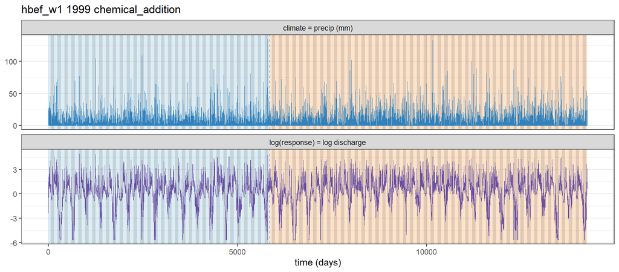

Figure 1. hbef_w1 — precip (climate) & log(discharge) over time, pre/post shaded, dashed = disturbance.

```r
plot_series(D[["hbef_w1"]], label["hbef_w1"])
```

```r
cat(kable(STATS[["hbef_w1"]], digits = 3, caption = "hbef_w1 — per-channel moments, settled pre/post"), sep = "\n")
```

hbef_w1 — per-channel moments, settled pre/post

| phase | series | mean | median | sd | var | IQR | range |
| --- | --- | --- | --- | --- | --- | --- | --- |
| pre | climate | 3.790 | 0.120 | 8.740 | 76.388 | 3.152 | 134.644 |
| pre | log_response | 0.045 | 0.294 | 1.765 | 3.116 | 1.721 | 10.577 |
| post | climate | 4.054 | 0.033 | 9.134 | 83.421 | 3.502 | 133.238 |
| post | log_response | 0.183 | 0.435 | 1.747 | 3.053 | 1.829 | 10.239 |

```r
cat("\n\n")
```

```r
cat(kable(SYNC[["hbef_w1"]] %>% select(-ends_with("_se")), digits = 2,
          caption = "hbef_w1 — peak-derived synchrony, pre vs post"), sep = "\n")
```

hbef_w1 — peak-derived synchrony, pre vs post

| phase | n | period_climate | period_response | period_resp_sd | amp_climate | amp_response | amp_ratio | phase_lag |
| --- | --- | --- | --- | --- | --- | --- | --- | --- |
| pre | 5844 | 397.64 | 361.93 | 18.68 | 8.74 | 1.77 | 0.20 | 219.81 |
| post | 8401 | 315.00 | 364.82 | 62.58 | 9.13 | 1.75 | 0.19 | 134.65 |

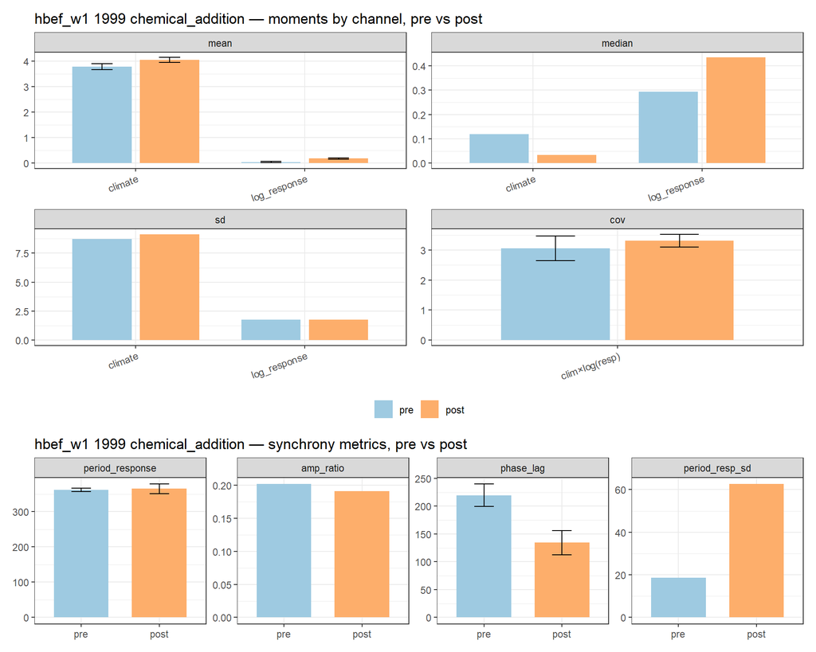

Figure 2. hbef_w1 — per-channel moments + joint covariance (top) and peak-derived synchrony metrics (bottom), pre vs post. Error bars = ±1 SE where defined.

```r
(plot_moments(STATS[["hbef_w1"]], D[["hbef_w1"]], paste(label["hbef_w1"], "— moments by channel, pre vs post"), errbar = TRUE) /
 plot_sync(SYNC[["hbef_w1"]], paste(label["hbef_w1"], "— synchrony metrics, pre vs post"))) +
  plot_layout(heights = c(2, 1))
```

# hjandrews_GSWS10 — debris flow (pulse)

HJ Andrews WS10, a small steep catchment, was scoured by a **1986 debris flow**. A physical channel disturbance can plausibly shift the storm→flow response; watch whether peak spacing or amplitude ratio moves beyond climate variability. *(Provenance: ~13% of this site’s precip is modelled infill — see the table above.)*

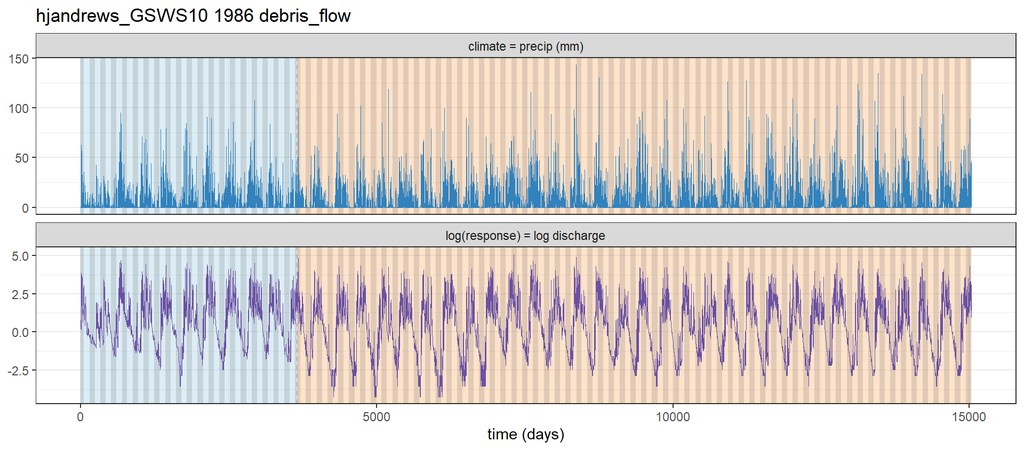

Figure 3. hjandrews_GSWS10 — precip & log(discharge), pre/post shaded, dashed = disturbance.

```r
plot_series(D[["hjandrews_GSWS10"]], label["hjandrews_GSWS10"])
```

```r
cat(kable(STATS[["hjandrews_GSWS10"]], digits = 3, caption = "hjandrews_GSWS10 — per-channel moments, settled pre/post"), sep = "\n")
```

hjandrews_GSWS10 — per-channel moments, settled pre/post

| phase | series | mean | median | sd | var | IQR | range |
| --- | --- | --- | --- | --- | --- | --- | --- |
| pre | climate | 5.536 | 0.007 | 11.329 | 128.335 | 6.130 | 107.705 |
| pre | log_response | 0.534 | 0.513 | 1.501 | 2.254 | 2.291 | 8.258 |
| post | climate | 6.600 | 0.027 | 13.363 | 178.580 | 7.642 | 143.094 |
| post | log_response | 0.139 | 0.307 | 1.831 | 3.354 | 2.933 | 9.338 |

```r
cat("\n\n")
```

```r
cat(kable(SYNC[["hjandrews_GSWS10"]] %>% select(-ends_with("_se")), digits = 2,
          caption = "hjandrews_GSWS10 — peak-derived synchrony, pre vs post"), sep = "\n")
```

hjandrews_GSWS10 — peak-derived synchrony, pre vs post

| phase | n | period_climate | period_response | period_resp_sd | amp_climate | amp_response | amp_ratio | phase_lag |
| --- | --- | --- | --- | --- | --- | --- | --- | --- |
| pre | 3653 | 352.80 | 356.30 | 53.59 | 11.33 | 1.50 | 0.13 | 21.27 |
| post | 11386 | 364.84 | 364.23 | 65.17 | 13.36 | 1.83 | 0.14 | 46.22 |

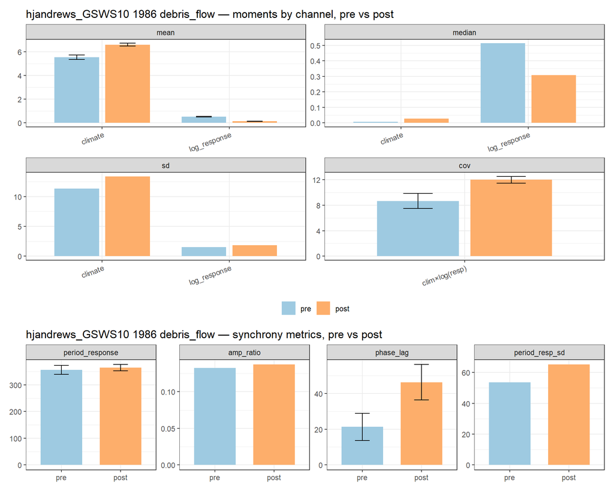

Figure 4. hjandrews_GSWS10 — moments + covariance (top) and synchrony metrics (bottom), pre vs post; ±1 SE where defined.

```r
(plot_moments(STATS[["hjandrews_GSWS10"]], D[["hjandrews_GSWS10"]], paste(label["hjandrews_GSWS10"], "— moments by channel, pre vs post"), errbar = TRUE) /
 plot_sync(SYNC[["hjandrews_GSWS10"]], paste(label["hjandrews_GSWS10"], "— synchrony metrics, pre vs post"))) +
  plot_layout(heights = c(2, 1))
```

# fernow_WS-3 — chemical addition (chronic)

Fernow WS3 has received **chronic artificial acidification** (ammonium sulfate) since 1989 — an *open-ended* treatment, so “post” is a persistently manipulated regime rather than a settled recovery. Like W1 the target is chemistry; a strong discharge signature is not expected, but the long records give this method many cycles to average.

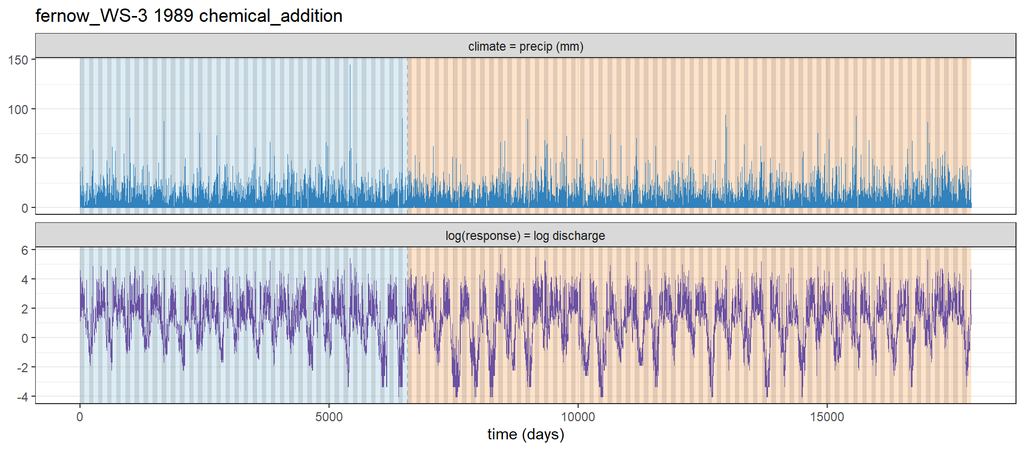

Figure 5. fernow_WS-3 — precip & log(discharge), pre/post shaded, dashed = disturbance.

```r
plot_series(D[["fernow_WS-3"]], label["fernow_WS-3"])
```

```r
cat(kable(STATS[["fernow_WS-3"]], digits = 3, caption = "fernow_WS-3 — per-channel moments, settled pre/post"), sep = "\n")
```

fernow_WS-3 — per-channel moments, settled pre/post

| phase | series | mean | median | sd | var | IQR | range |
| --- | --- | --- | --- | --- | --- | --- | --- |
| pre | climate | 4.106 | 0.00 | 8.109 | 65.758 | 4.830 | 144.530 |
| pre | log_response | 1.185 | 1.35 | 1.449 | 2.099 | 1.942 | 9.435 |
| post | climate | 4.182 | 0.00 | 8.333 | 69.434 | 4.830 | 93.730 |
| post | log_response | 0.925 | 1.29 | 1.738 | 3.019 | 2.382 | 9.695 |

```r
cat("\n\n")
```

```r
cat(kable(SYNC[["fernow_WS-3"]] %>% select(-ends_with("_se")), digits = 2,
          caption = "fernow_WS-3 — peak-derived synchrony, pre vs post"), sep = "\n")
```

fernow_WS-3 — peak-derived synchrony, pre vs post

| phase | n | period_climate | period_response | period_resp_sd | amp_climate | amp_response | amp_ratio | phase_lag |
| --- | --- | --- | --- | --- | --- | --- | --- | --- |
| pre | 6575 | 278.57 | 369.88 | 79.93 | 8.11 | 1.45 | 0.18 | 155.22 |
| post | 11321 | 332.88 | 362.50 | 54.80 | 8.33 | 1.74 | 0.21 | 152.48 |

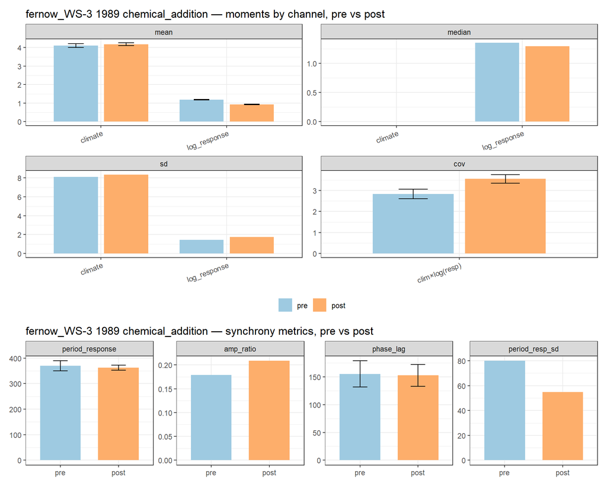

Figure 6. fernow_WS-3 — moments + covariance (top) and synchrony metrics (bottom), pre vs post; ±1 SE where defined.

```r
(plot_moments(STATS[["fernow_WS-3"]], D[["fernow_WS-3"]], paste(label["fernow_WS-3"], "— moments by channel, pre vs post"), errbar = TRUE) /
 plot_sync(SYNC[["fernow_WS-3"]], paste(label["fernow_WS-3"], "— synchrony metrics, pre vs post"))) +
  plot_layout(heights = c(2, 1))
```

# fernow_WS-5 — timber harvest (pulse)

Fernow WS5 was **clearcut in 2007**. Forest removal is the classic water-yield disturbance — reduced transpiration raises discharge and can sharpen the storm response — so this is the site where the **precip→discharge lens should have the most to see**.

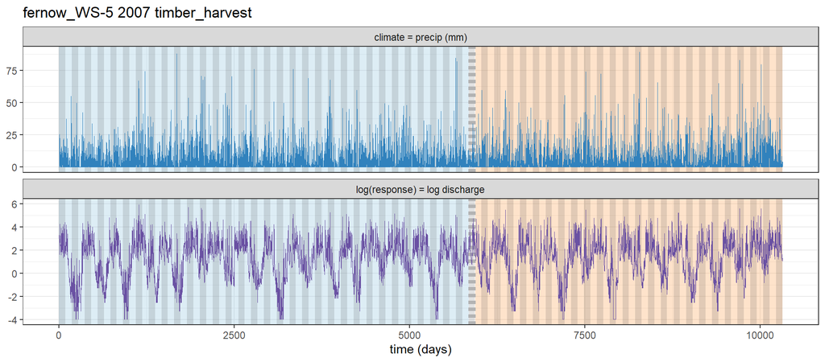

Figure 7. fernow_WS-5 — precip & log(discharge), pre/post shaded, dashed = disturbance.

```r
plot_series(D[["fernow_WS-5"]], label["fernow_WS-5"])
```

```r
cat(kable(STATS[["fernow_WS-5"]], digits = 3, caption = "fernow_WS-5 — per-channel moments, settled pre/post"), sep = "\n")
```

fernow_WS-5 — per-channel moments, settled pre/post

| phase | series | mean | median | sd | var | IQR | range |
| --- | --- | --- | --- | --- | --- | --- | --- |
| pre | climate | 4.011 | 0.000 | 8.227 | 67.687 | 4.320 | 88.140 |
| pre | log_response | 1.150 | 1.486 | 1.748 | 3.056 | 2.384 | 9.891 |
| post | climate | 4.196 | 0.000 | 8.384 | 70.299 | 4.830 | 89.150 |
| post | log_response | 1.244 | 1.513 | 1.702 | 2.896 | 2.181 | 9.552 |

```r
cat("\n\n")
```

```r
cat(kable(SYNC[["fernow_WS-5"]] %>% select(-ends_with("_se")), digits = 2,
          caption = "fernow_WS-5 — peak-derived synchrony, pre vs post"), sep = "\n")
```

fernow_WS-5 — peak-derived synchrony, pre vs post

| phase | n | period_climate | period_response | period_resp_sd | amp_climate | amp_response | amp_ratio | phase_lag |
| --- | --- | --- | --- | --- | --- | --- | --- | --- |
| pre | 5844 | 278.4 | 358.31 | 31.78 | 8.23 | 1.75 | 0.21 | 124.53 |
| post | 4383 | 349.0 | 353.73 | 83.02 | 8.38 | 1.70 | 0.20 | 211.33 |

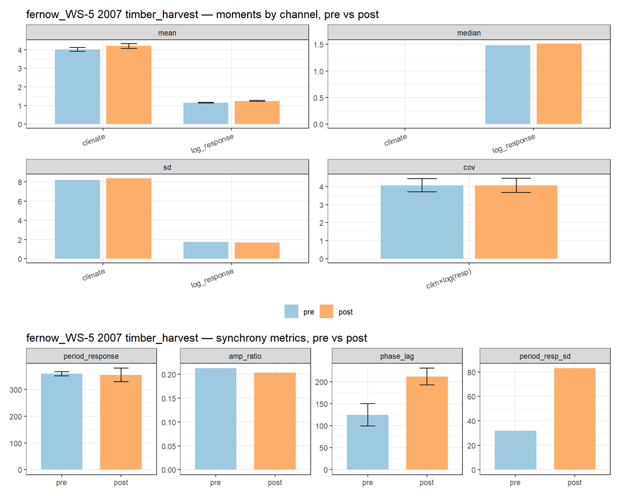

Figure 8. fernow_WS-5 — moments + covariance (top) and synchrony metrics (bottom), pre vs post; ±1 SE where defined.

```r
(plot_moments(STATS[["fernow_WS-5"]], D[["fernow_WS-5"]], paste(label["fernow_WS-5"], "— moments by channel, pre vs post"), errbar = TRUE) /
 plot_sync(SYNC[["fernow_WS-5"]], paste(label["fernow_WS-5"], "— synchrony metrics, pre vs post"))) +
  plot_layout(heights = c(2, 1))
```

# Cross-site summary

Post-minus-pre change in the peak-synchrony discriminators across the four sites. Read against analysis I’s synthetic result: there the three scenarios cleanly separated (Shift moved amp ratio + lag, Desync spiked period-sd, Return sat at zero). On real data the question is different — **how legibly does this method register anything at all**, and which sites move beyond the climate-driven pre/post wobble. (`MC06` is dropped — its precip driver is ~88% modelled infill; it remains in the EDA, where its coverage is now shown.)

```r
sync_all <- bind_rows(SYNC, .id = "site")
delta <- sync_all %>%
  select(site, phase, amp_ratio, phase_lag, period_resp_sd) %>%
  pivot_longer(c(amp_ratio, phase_lag, period_resp_sd), names_to = "metric") %>%
  pivot_wider(names_from = phase, values_from = value) %>%
  mutate(delta = post - pre, site = factor(site, sites))
```

```r
cat(kable(delta %>% select(site, metric, pre, post, delta), digits = 2,
          caption = "pre → post change in synchrony discriminators, all sites"), sep = "\n")
```

pre → post change in synchrony discriminators, all sites

| site | metric | pre | post | delta |
| --- | --- | --- | --- | --- |
| hbef_w1 | amp_ratio | 0.20 | 0.19 | -0.01 |
| hbef_w1 | phase_lag | 219.81 | 134.65 | -85.16 |
| hbef_w1 | period_resp_sd | 18.68 | 62.58 | 43.90 |
| hjandrews_GSWS10 | amp_ratio | 0.13 | 0.14 | 0.00 |
| hjandrews_GSWS10 | phase_lag | 21.27 | 46.22 | 24.95 |
| hjandrews_GSWS10 | period_resp_sd | 53.59 | 65.17 | 11.58 |
| fernow_WS-3 | amp_ratio | 0.18 | 0.21 | 0.03 |
| fernow_WS-3 | phase_lag | 155.22 | 152.48 | -2.74 |
| fernow_WS-3 | period_resp_sd | 79.93 | 54.80 | -25.13 |
| fernow_WS-5 | amp_ratio | 0.21 | 0.20 | -0.01 |
| fernow_WS-5 | phase_lag | 124.53 | 211.33 | 86.80 |
| fernow_WS-5 | period_resp_sd | 31.78 | 83.02 | 51.24 |

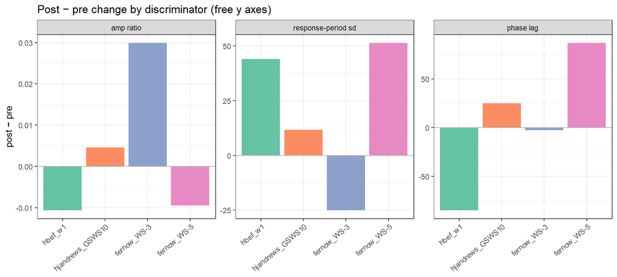

Figure 9. Post − pre change per site, faceted by discriminator (free y). Unlike the synthetic scenarios these do not fall into tidy signatures — the peak/moments lens gives a noisy, partial read on real coupling, motivating the wavelet view in analysis IV.

```r
ggplot(delta, aes(site, delta, fill = site)) +
  geom_col() +
  geom_hline(yintercept = 0, colour = "grey70") +
  facet_wrap(~ metric, scales = "free_y",
             labeller = as_labeller(c(amp_ratio = "amp ratio", phase_lag = "phase lag",
                                      period_resp_sd = "response-period sd"))) +
  scale_fill_brewer(palette = "Set2", guide = "none") +
  labs(title = "Post − pre change by discriminator (free y axes)", x = NULL, y = "post − pre") +
  theme(axis.text.x = element_text(angle = 40, hjust = 1))
```